# Stepwise Multiple Regressions

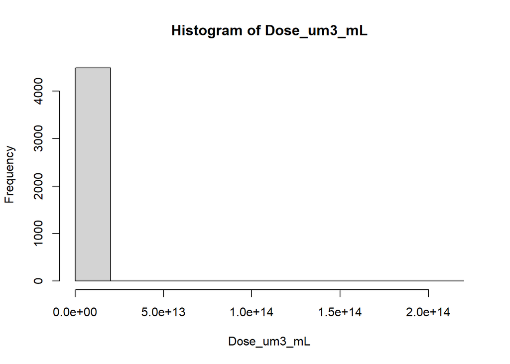

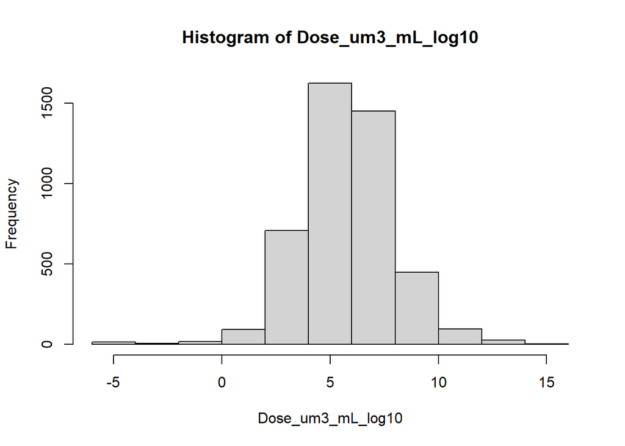

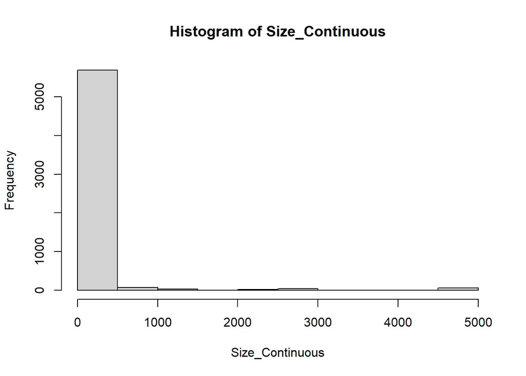

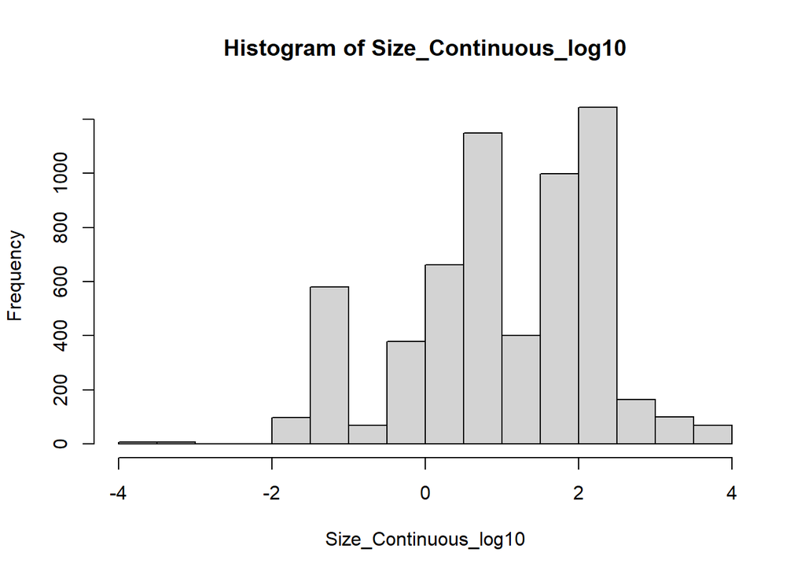

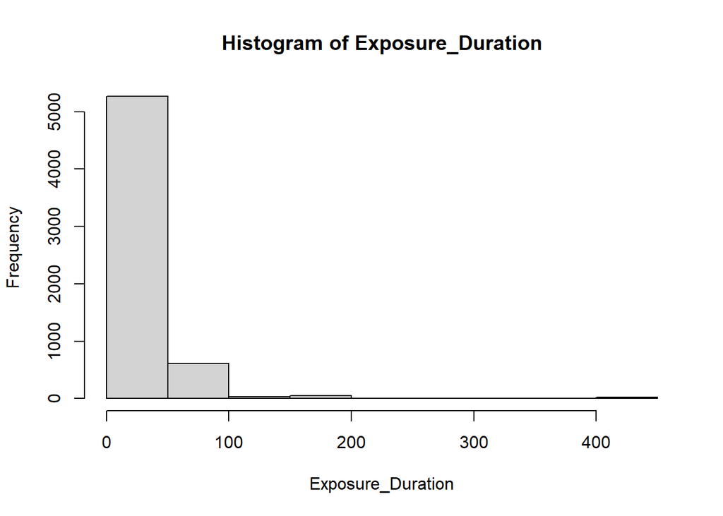

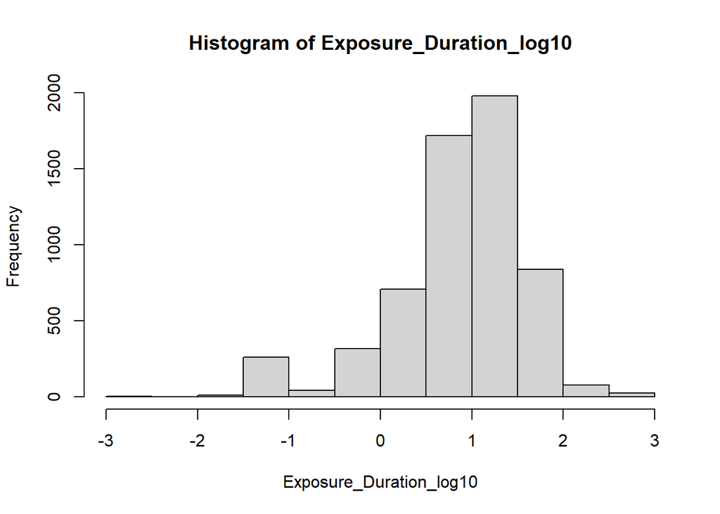

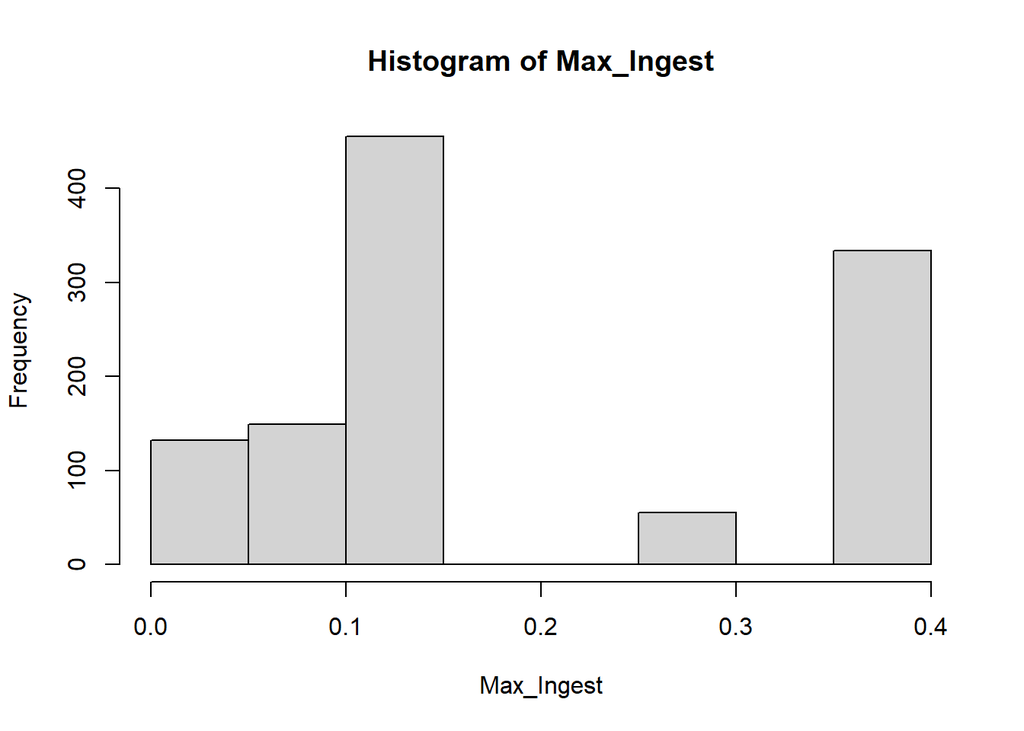

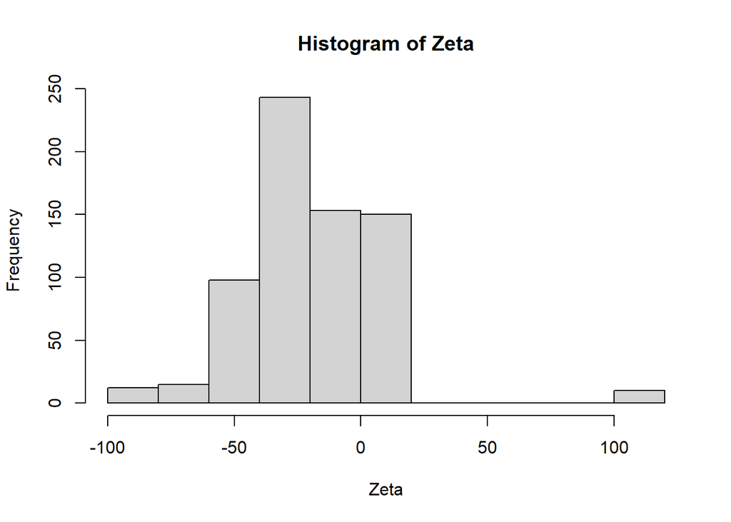

#Model - Log Transformed

Doses (count, mass and volume), size (continuous), and exposure duration are all log transformed given histogram results.

The model starts with the following independent variables: 1. Dose (count) 2. Dose (mass) 3. Dose (volume) 4. Size (continuous) 5. Size (binned) 6. Shape 7. Polymer 8. Exposure Duration 9. Level of Biological Organization 10. Charge (negative/positive) 11. Particle Source 12. Organism Group - substitute for body right now

## 2.5 All Variables: Acute

Add all variables back in but only use acute data (fish, crustaceans, mollucs, and algae)

Full Model

```
##
## Call:
## lm(formula = effect_f ~ ., data = y, na.action = na.omit)
##
## Residuals:
##     Min      1Q  Median      3Q     Max
## -0.6998 -0.3518 -0.1794  0.5069  0.9589
##
## Coefficients: (2 not defined because of singularities)
##                                                Estimate Std. Error t value
## (Intercept)                                   3.601e+01  4.082e+01   0.882
## `log10(dose.particles.mL.master)`            -1.243e+02  1.451e+02  -0.856
## `log10(dose.mg.L.master)`                    -4.919e-02  2.828e-02  -1.739
## `log10(dose.um3.mL.master)`                   1.244e+02  1.451e+02   0.857
## `log10(size.length.um.used.for.conversions)` -3.729e+02  4.354e+02  -0.857
## size_f                                        9.331e-02  7.952e-02   1.173
## poly_f                                               NA         NA      NA
## shape_f                                              NA         NA      NA
## org_f                                        -4.393e-02  1.827e-02  -2.405
## life_f                                       -1.172e-02  4.657e-02  -0.252
## bio_f                                         3.209e-02  1.880e-02   1.706
## `log10(exposure.duration.d)`                  5.745e-02  4.487e-02   1.280
## charge_f                                     -1.994e-01  8.982e-02  -2.220
## zetapotential.mV                              5.704e-03  1.325e-03   4.305
## particle_source_f                             2.977e-01  1.646e-01   1.809
##                                              Pr(>|t|)
## (Intercept)                                    0.3781
## `log10(dose.particles.mL.master)`              0.3922
## `log10(dose.mg.L.master)`                      0.0826 .
## `log10(dose.um3.mL.master)`                    0.3919
## `log10(size.length.um.used.for.conversions)`   0.3921
## size_f                                         0.2412
## poly_f                                             NA
## shape_f                                            NA
## org_f                                          0.0166 *
## life_f                                         0.8014
## bio_f                                          0.0886 .
## `log10(exposure.duration.d)`                   0.2010
## charge_f                                       0.0269 *
## zetapotential.mV                             2.03e-05 ***
## particle_source_f                              0.0711 .
## ---
## Signif. codes:  0 '***' 0.001 '**' 0.01 '*' 0.05 '.' 0.1 ' ' 1
##
## Residual standard error: 0.4495 on 484 degrees of freedom
## Multiple R-squared:  0.1521, Adjusted R-squared:  0.1311
## F-statistic: 7.235 on 12 and 484 DF,  p-value: 3.075e-12
```

Stepwise Model - Both Directions

```
##
## Call:
## lm(formula = effect_f ~ `log10(dose.mg.L.master)` + `log10(dose.um3.mL.master)` +
##     size_f + org_f + bio_f + `log10(exposure.duration.d)` + charge_f +
##     zetapotential.mV + particle_source_f, data = y, na.action = na.omit)
##
## Residuals:
##     Min      1Q  Median      3Q     Max
## -0.7291 -0.3596 -0.1944  0.5062  0.9495
##
## Coefficients:
##                               Estimate Std. Error t value Pr(>|t|)
## (Intercept)                   0.992554   0.234418   4.234 2.74e-05 ***
## `log10(dose.mg.L.master)`    -0.059356   0.025596  -2.319  0.02081 *
## `log10(dose.um3.mL.master)`   0.079757   0.025161   3.170  0.00162 **
## size_f                        0.067173   0.028574   2.351  0.01913 *
## org_f                        -0.046269   0.010784  -4.290 2.15e-05 ***
## bio_f                         0.035614   0.017888   1.991  0.04705 *
## `log10(exposure.duration.d)`  0.073146   0.036133   2.024  0.04348 *
## charge_f                     -0.204856   0.087706  -2.336  0.01991 *
## zetapotential.mV              0.005557   0.001280   4.343 1.71e-05 ***
## particle_source_f             0.362018   0.150182   2.411  0.01630 *
## ---
## Signif. codes:  0 '***' 0.001 '**' 0.01 '*' 0.05 '.' 0.1 ' ' 1
##
## Residual standard error: 0.4486 on 487 degrees of freedom
## Multiple R-squared:  0.1502, Adjusted R-squared:  0.1345
## F-statistic: 9.565 on 9 and 487 DF,  p-value: 1.745e-13
```

## 2.6 All Variables: Chronic

Add all variables back in but only use chronic data (fish, crustaceans, mollucs, and algae)

Full Model

```
##
## Call:
## lm(formula = effect_f ~ ., data = y, na.action = na.omit)
##
## Residuals:
##     Min      1Q  Median      3Q     Max
## -0.5714 -0.3000  0.0000  0.2143  0.7714
##
## Coefficients: (9 not defined because of singularities)
##                                                Estimate Std. Error t value
## (Intercept)                                   2.521e+03  1.153e+04   0.219
## `log10(dose.particles.mL.master)`            -8.968e+03  2.160e+04  -0.415
## `log10(dose.mg.L.master)`                    -1.681e-07  1.282e+03   0.000
## `log10(dose.um3.mL.master)`                   8.968e+03  2.112e+04   0.425
## `log10(size.length.um.used.for.conversions)` -2.690e+04  6.480e+04  -0.415
## size_f                                               NA         NA      NA
## poly_f                                               NA         NA      NA
## shape_f                                              NA         NA      NA
## org_f                                                NA         NA      NA
## life_f                                               NA         NA      NA
## bio_f                                         6.667e-02  9.518e-02   0.700
## `log10(exposure.duration.d)`                         NA         NA      NA
## charge_f                                             NA         NA      NA
## zetapotential.mV                                     NA         NA      NA
## particle_source_f                                    NA         NA      NA
##                                              Pr(>|t|)
## (Intercept)                                     0.830
## `log10(dose.particles.mL.master)`               0.685
## `log10(dose.mg.L.master)`                       1.000
## `log10(dose.um3.mL.master)`                     0.678
## `log10(size.length.um.used.for.conversions)`    0.685
## size_f                                             NA
## poly_f                                             NA
## shape_f                                            NA
## org_f                                              NA
## life_f                                             NA
## bio_f                                           0.496
## `log10(exposure.duration.d)`                       NA
## charge_f                                           NA
## zetapotential.mV                                   NA
## particle_source_f                                  NA
##
## Residual standard error: 0.4827 on 13 degrees of freedom
## Multiple R-squared:  0.178,  Adjusted R-squared:  -0.1382
## F-statistic: 0.5629 on 5 and 13 DF,  p-value: 0.727
```

Stepwise Model - Both Directions

```
##
## Call:
## lm(formula = effect_f ~ `log10(dose.particles.mL.master)`, data = y,
##     na.action = na.omit)
##
## Residuals:
##      Min       1Q   Median       3Q      Max
## -0.36857 -0.34873 -0.01804  0.32541  0.65127
##
## Coefficients:
##                                   Estimate Std. Error t value Pr(>|t|)
## (Intercept)                        1.62234    0.24428   6.641 4.17e-06 ***
## `log10(dose.particles.mL.master)` -0.05358    0.03328  -1.610    0.126
## ---
## Signif. codes:  0 '***' 0.001 '**' 0.01 '*' 0.05 '.' 0.1 ' ' 1
##
## Residual standard error: 0.4336 on 17 degrees of freedom
## Multiple R-squared:  0.1323, Adjusted R-squared:  0.08125
## F-statistic: 2.592 on 1 and 17 DF,  p-value: 0.1258
```

# 3 Model: All Independent Variables, Response Variable: Effect (Y/N) x Effect Score

Full Model

[output not shown]

Stepwise Model - Both Directions

[output not shown]

### Full

```
##
## Call:
## lm(formula = effect_f ~ ., data = y)
##
## Residuals:
##     Min      1Q  Median      3Q     Max
## -0.6301 -0.3678 -0.2209  0.5500  1.0191
##
## Coefficients:
##                                               Estimate Std. Error t value
## (Intercept)                                   1.620202   0.145827  11.110
## `log10(dose.particles.mL.master)`            -0.208747   0.053262  -3.919
## `log10(dose.mg.L.master)`                     0.041562   0.007950   5.228
## size_f                                        0.030963   0.021268   1.456
## `log10(size.length.um.used.for.conversions)` -0.654551   0.159629  -4.100
## shape_f                                      -0.147737   0.038247  -3.863
## poly_f                                        0.019279   0.002287   8.430
## `log10(dose.um3.mL.master)`                   0.189719   0.054390   3.488
## `log10(exposure.duration.d)`                  0.033783   0.010528   3.209
## bio_f                                         0.037126   0.006628   5.602
## charge_f                                      0.032724   0.019362   1.690
## particle_source_f                            -0.021994   0.013242  -1.661
## org_f                                        -0.015954   0.003197  -4.991
##                                              Pr(>|t|)
## (Intercept)                                   < 2e-16 ***
## `log10(dose.particles.mL.master)`            9.02e-05 ***
## `log10(dose.mg.L.master)`                    1.79e-07 ***
## size_f                                       0.145498
## `log10(size.length.um.used.for.conversions)` 4.20e-05 ***
## shape_f                                      0.000114 ***
## poly_f                                        < 2e-16 ***
## `log10(dose.um3.mL.master)`                  0.000491 ***
## `log10(exposure.duration.d)`                 0.001342 **
## bio_f                                        2.25e-08 ***
## charge_f                                     0.091072 .
## particle_source_f                            0.096794 .
## org_f                                        6.24e-07 ***
## ---
## Signif. codes:  0 '***' 0.001 '**' 0.01 '*' 0.05 '.' 0.1 ' ' 1
##
## Residual standard error: 0.4561 on 4363 degrees of freedom
## Multiple R-squared:  0.06026,    Adjusted R-squared:  0.05767
## F-statistic: 23.31 on 12 and 4363 DF,  p-value: < 2.2e-16
```

### Stepwise

```
##
## Call:
## lm(formula = effect_f ~ `log10(dose.particles.mL.master)` + `log10(dose.mg.L.master)` +
##     size_f + `log10(size.length.um.used.for.conversions)` + shape_f +
##     poly_f + `log10(dose.um3.mL.master)` + `log10(exposure.duration.d)` +
##     bio_f + charge_f + particle_source_f + org_f, data = y)
##
## Residuals:
##     Min      1Q  Median      3Q     Max
## -0.6301 -0.3678 -0.2209  0.5500  1.0191
##
## Coefficients:
##                                               Estimate Std. Error t value
## (Intercept)                                   1.620202   0.145827  11.110
## `log10(dose.particles.mL.master)`            -0.208747   0.053262  -3.919
## `log10(dose.mg.L.master)`                     0.041562   0.007950   5.228
## size_f                                        0.030963   0.021268   1.456
## `log10(size.length.um.used.for.conversions)` -0.654551   0.159629  -4.100
## shape_f                                      -0.147737   0.038247  -3.863
## poly_f                                        0.019279   0.002287   8.430
## `log10(dose.um3.mL.master)`                   0.189719   0.054390   3.488
## `log10(exposure.duration.d)`                  0.033783   0.010528   3.209
## bio_f                                         0.037126   0.006628   5.602
## charge_f                                      0.032724   0.019362   1.690
## particle_source_f                            -0.021994   0.013242  -1.661
## org_f                                        -0.015954   0.003197  -4.991
##                                              Pr(>|t|)
## (Intercept)                                   < 2e-16 ***
## `log10(dose.particles.mL.master)`            9.02e-05 ***
## `log10(dose.mg.L.master)`                    1.79e-07 ***
## size_f                                       0.145498
## `log10(size.length.um.used.for.conversions)` 4.20e-05 ***
## shape_f                                      0.000114 ***
## poly_f                                        < 2e-16 ***
## `log10(dose.um3.mL.master)`                  0.000491 ***
## `log10(exposure.duration.d)`                 0.001342 **
## bio_f                                        2.25e-08 ***
## charge_f                                     0.091072 .
## particle_source_f                            0.096794 .
## org_f                                        6.24e-07 ***
## ---
## Signif. codes:  0 '***' 0.001 '**' 0.01 '*' 0.05 '.' 0.1 ' ' 1
##
## Residual standard error: 0.4561 on 4363 degrees of freedom
## Multiple R-squared:  0.06026,    Adjusted R-squared:  0.05767
## F-statistic: 23.31 on 12 and 4363 DF,  p-value: < 2.2e-16
```

#Model Refining

##Remove Charge

Complete charge data are limited to PS and PC spheres - remove to include for complete data.

The model starts with the following independent variables: 1. Dose (count) 2. Dose (mass) 3. Dose (volume) 4. Size (continuous) 5. Size (binned) 6. Shape 7. Polymer 8. Exposure Duration 9. Level of Biological Organization 10. Charge (negative/positive) 11. Particle Source 12. Organism Group - substitute for body right now

## 3.1 Remove Charge and Zeta Potential

Missing categories (NA) means that some data are incomplete. This is likely charge and zeta potential which are only in the database for PS and PC spheres. Removed from model to retain more data.

Full Model

```
##
## Call:
## lm(formula = effect_f * effect.score ~ ., data = y, na.action = na.omit)
##
## Residuals:
##     Min      1Q  Median      3Q     Max
## -6.4047 -1.0217 -0.3641  0.6406  9.3158
##
## Coefficients:
##                                              Estimate Std. Error t value
## (Intercept)                                  12.72077    0.63575  20.009
## `log10(dose.particles.mL.master)`            -1.45005    0.23436  -6.187
## `log10(dose.mg.L.master)`                     0.23940    0.03528   6.785
## `log10(dose.um3.mL.master)`                   1.37721    0.23982   5.743
## `log10(size.length.um.used.for.conversions)` -4.83273    0.70213  -6.883
## size_f                                        0.01405    0.09276   0.152
## poly_f                                       -0.10480    0.01010 -10.377
## shape_f                                      -1.53343    0.16835  -9.109
## org_f                                         0.03514    0.01625   2.162
## life_f                                       -0.45045    0.03973 -11.338
## bio_f                                        -0.91906    0.02962 -31.027
## `log10(exposure.duration.d)`                  0.40396    0.04937   8.182
## acute.chronic_f                              -0.12352    0.05379  -2.296
## particle_source_f                             0.05383    0.05823   0.924
##                                              Pr(>|t|)
## (Intercept)                                   < 2e-16 ***
## `log10(dose.particles.mL.master)`            6.68e-10 ***
## `log10(dose.mg.L.master)`                    1.31e-11 ***
## `log10(dose.um3.mL.master)`                  9.95e-09 ***
## `log10(size.length.um.used.for.conversions)` 6.70e-12 ***
## size_f                                         0.8796
## poly_f                                        < 2e-16 ***
## shape_f                                       < 2e-16 ***
## org_f                                          0.0306 *
## life_f                                        < 2e-16 ***
## bio_f                                         < 2e-16 ***
## `log10(exposure.duration.d)`                 3.63e-16 ***
## acute.chronic_f                                0.0217 *
## particle_source_f                              0.3553
## ---
## Signif. codes:  0 '***' 0.001 '**' 0.01 '*' 0.05 '.' 0.1 ' ' 1
##
## Residual standard error: 1.991 on 4362 degrees of freedom
## Multiple R-squared:  0.3062, Adjusted R-squared:  0.3041
## F-statistic: 148.1 on 13 and 4362 DF,  p-value: < 2.2e-16
```

Stepwise Model - Both Directions

[output not shown]

### Full

```
##
## Call:
## lm(formula = effect_f ~ ., data = y)
##
## Residuals:
##     Min      1Q  Median      3Q     Max
## -0.6268 -0.3680 -0.2184  0.5533  1.0159
##
## Coefficients:
##                                               Estimate Std. Error t value
## (Intercept)                                   1.675082   0.142196  11.780
## `log10(dose.particles.mL.master)`            -0.207742   0.053271  -3.900
## `log10(dose.mg.L.master)`                     0.040921   0.007942   5.152
## size_f                                        0.032476   0.021254   1.528
## `log10(size.length.um.used.for.conversions)` -0.651106   0.159650  -4.078
## shape_f                                      -0.147323   0.038255  -3.851
## poly_f                                        0.018998   0.002281   8.328
## `log10(dose.um3.mL.master)`                   0.189367   0.054402   3.481
## `log10(exposure.duration.d)`                  0.033969   0.010529   3.226
## bio_f                                         0.037567   0.006624   5.671
## particle_source_f                            -0.022175   0.013244  -1.674
## org_f                                        -0.016030   0.003197  -5.014
##                                              Pr(>|t|)
## (Intercept)                                   < 2e-16 ***
## `log10(dose.particles.mL.master)`            9.77e-05 ***
## `log10(dose.mg.L.master)`                    2.69e-07 ***
## size_f                                       0.126573
## `log10(size.length.um.used.for.conversions)` 4.62e-05 ***
## shape_f                                      0.000119 ***
## poly_f                                        < 2e-16 ***
## `log10(dose.um3.mL.master)`                  0.000505 ***
## `log10(exposure.duration.d)`                 0.001264 **
## bio_f                                        1.51e-08 ***
## particle_source_f                            0.094133 .
## org_f                                        5.54e-07 ***
## ---
## Signif. codes:  0 '***' 0.001 '**' 0.01 '*' 0.05 '.' 0.1 ' ' 1
##
## Residual standard error: 0.4562 on 4364 degrees of freedom
## Multiple R-squared:  0.05964,    Adjusted R-squared:  0.05727
## F-statistic: 25.16 on 11 and 4364 DF,  p-value: < 2.2e-16
```

### Stepwise

```
##
## Call:
## lm(formula = effect_f ~ `log10(dose.particles.mL.master)` + `log10(dose.mg.L.master)` +
##     size_f + `log10(size.length.um.used.for.conversions)` + shape_f +
##     poly_f + `log10(dose.um3.mL.master)` + `log10(exposure.duration.d)` +
##     bio_f + particle_source_f + org_f, data = y)
##
## Residuals:
##     Min      1Q  Median      3Q     Max
## -0.6268 -0.3680 -0.2184  0.5533  1.0159
##
## Coefficients:
##                                               Estimate Std. Error t value
## (Intercept)                                   1.675082   0.142196  11.780
## `log10(dose.particles.mL.master)`            -0.207742   0.053271  -3.900
## `log10(dose.mg.L.master)`                     0.040921   0.007942   5.152
## size_f                                        0.032476   0.021254   1.528
## `log10(size.length.um.used.for.conversions)` -0.651106   0.159650  -4.078
## shape_f                                      -0.147323   0.038255  -3.851
## poly_f                                        0.018998   0.002281   8.328
## `log10(dose.um3.mL.master)`                   0.189367   0.054402   3.481
## `log10(exposure.duration.d)`                  0.033969   0.010529   3.226
## bio_f                                         0.037567   0.006624   5.671
## particle_source_f                            -0.022175   0.013244  -1.674
## org_f                                        -0.016030   0.003197  -5.014
##                                              Pr(>|t|)
## (Intercept)                                   < 2e-16 ***
## `log10(dose.particles.mL.master)`            9.77e-05 ***
## `log10(dose.mg.L.master)`                    2.69e-07 ***
## size_f                                       0.126573
## `log10(size.length.um.used.for.conversions)` 4.62e-05 ***
## shape_f                                      0.000119 ***
## poly_f                                        < 2e-16 ***
## `log10(dose.um3.mL.master)`                  0.000505 ***
## `log10(exposure.duration.d)`                 0.001264 **
## bio_f                                        1.51e-08 ***
## particle_source_f                            0.094133 .
## org_f                                        5.54e-07 ***
## ---
## Signif. codes:  0 '***' 0.001 '**' 0.01 '*' 0.05 '.' 0.1 ' ' 1
##
## Residual standard error: 0.4562 on 4364 degrees of freedom
## Multiple R-squared:  0.05964,    Adjusted R-squared:  0.05727
## F-statistic: 25.16 on 11 and 4364 DF,  p-value: < 2.2e-16
```

##Remove Charge + Size (binned)

Size (binned) had the highest p value in the last model - removed.

## 3.2 Remove Size (binned)

Size (binned) not significant - removed from model.

Full Model

```
##
## Call:
## lm(formula = effect_f * effect.score ~ ., data = y, na.action = na.omit)
##
## Residuals:
##     Min      1Q  Median      3Q     Max
## -6.4087 -1.0190 -0.3701  0.6366  9.3070
##
## Coefficients:
##                                              Estimate Std. Error t value
## (Intercept)                                  12.75114    0.60325  21.138
## `log10(dose.particles.mL.master)`            -1.45189    0.23402  -6.204
## `log10(dose.mg.L.master)`                     0.23908    0.03522   6.789
## `log10(dose.um3.mL.master)`                   1.37923    0.23942   5.761
## `log10(size.length.um.used.for.conversions)` -4.82781    0.70130  -6.884
## poly_f                                       -0.10491    0.01007 -10.417
## shape_f                                      -1.53172    0.16795  -9.120
## org_f                                         0.03505    0.01624   2.159
## life_f                                       -0.45054    0.03972 -11.343
## bio_f                                        -0.91984    0.02916 -31.539
## `log10(exposure.duration.d)`                  0.40404    0.04936   8.185
## acute.chronic_f                              -0.12342    0.05378  -2.295
## particle_source_f                             0.05429    0.05814   0.934
##                                              Pr(>|t|)
## (Intercept)                                   < 2e-16 ***
## `log10(dose.particles.mL.master)`            6.01e-10 ***
## `log10(dose.mg.L.master)`                    1.28e-11 ***
## `log10(dose.um3.mL.master)`                  8.95e-09 ***
## `log10(size.length.um.used.for.conversions)` 6.65e-12 ***
## poly_f                                        < 2e-16 ***
## shape_f                                       < 2e-16 ***
## org_f                                          0.0309 *
## life_f                                        < 2e-16 ***
## bio_f                                         < 2e-16 ***
## `log10(exposure.duration.d)`                 3.54e-16 ***
## acute.chronic_f                                0.0218 *
## particle_source_f                              0.3504
## ---
## Signif. codes:  0 '***' 0.001 '**' 0.01 '*' 0.05 '.' 0.1 ' ' 1
##
## Residual standard error: 1.991 on 4363 degrees of freedom
## Multiple R-squared:  0.3062, Adjusted R-squared:  0.3043
## F-statistic: 160.5 on 12 and 4363 DF,  p-value: < 2.2e-16
```

Stepwise Model - Both Directions

[output not shown]

### Full

```
##
## Call:
## lm(formula = effect_f ~ ., data = y)
##
## Residuals:
##     Min      1Q  Median      3Q     Max
## -0.6018 -0.3654 -0.2299  0.5526  1.0202
##
## Coefficients:
##                                               Estimate Std. Error t value
## (Intercept)                                   1.744748   0.134710  12.952
## `log10(dose.particles.mL.master)`            -0.211910   0.053209  -3.983
## `log10(dose.mg.L.master)`                     0.040211   0.007930   5.071
## `log10(size.length.um.used.for.conversions)` -0.639498   0.159494  -4.010
## shape_f                                      -0.143308   0.038170  -3.754
## poly_f                                        0.018752   0.002276   8.239
## `log10(dose.um3.mL.master)`                   0.193925   0.054328   3.570
## `log10(exposure.duration.d)`                  0.034249   0.010529   3.253
## bio_f                                         0.035753   0.006518   5.486
## particle_source_f                            -0.021057   0.013226  -1.592
## org_f                                        -0.016192   0.003196  -5.067
##                                              Pr(>|t|)
## (Intercept)                                   < 2e-16 ***
## `log10(dose.particles.mL.master)`            6.93e-05 ***
## `log10(dose.mg.L.master)`                    4.12e-07 ***
## `log10(size.length.um.used.for.conversions)` 6.19e-05 ***
## shape_f                                      0.000176 ***
## poly_f                                       2.27e-16 ***
## `log10(dose.um3.mL.master)`                  0.000361 ***
## `log10(exposure.duration.d)`                 0.001152 **
## bio_f                                        4.35e-08 ***
## particle_source_f                            0.111429
## org_f                                        4.21e-07 ***
## ---
## Signif. codes:  0 '***' 0.001 '**' 0.01 '*' 0.05 '.' 0.1 ' ' 1
##
## Residual standard error: 0.4563 on 4365 degrees of freedom
## Multiple R-squared:  0.05914,    Adjusted R-squared:  0.05698
## F-statistic: 27.44 on 10 and 4365 DF,  p-value: < 2.2e-16
```

### Stepwise

```
##
## Call:
## lm(formula = effect_f ~ `log10(dose.particles.mL.master)` + `log10(dose.mg.L.master)` +
##     `log10(size.length.um.used.for.conversions)` + shape_f +
##     poly_f + `log10(dose.um3.mL.master)` + `log10(exposure.duration.d)` +
##     bio_f + particle_source_f + org_f, data = y)
##
## Residuals:
##     Min      1Q  Median      3Q     Max
## -0.6018 -0.3654 -0.2299  0.5526  1.0202
##
## Coefficients:
##                                               Estimate Std. Error t value
## (Intercept)                                   1.744748   0.134710  12.952
## `log10(dose.particles.mL.master)`            -0.211910   0.053209  -3.983
## `log10(dose.mg.L.master)`                     0.040211   0.007930   5.071
## `log10(size.length.um.used.for.conversions)` -0.639498   0.159494  -4.010
## shape_f                                      -0.143308   0.038170  -3.754
## poly_f                                        0.018752   0.002276   8.239
## `log10(dose.um3.mL.master)`                   0.193925   0.054328   3.570
## `log10(exposure.duration.d)`                  0.034249   0.010529   3.253
## bio_f                                         0.035753   0.006518   5.486
## particle_source_f                            -0.021057   0.013226  -1.592
## org_f                                        -0.016192   0.003196  -5.067
##                                              Pr(>|t|)
## (Intercept)                                   < 2e-16 ***
## `log10(dose.particles.mL.master)`            6.93e-05 ***
## `log10(dose.mg.L.master)`                    4.12e-07 ***
## `log10(size.length.um.used.for.conversions)` 6.19e-05 ***
## shape_f                                      0.000176 ***
## poly_f                                       2.27e-16 ***
## `log10(dose.um3.mL.master)`                  0.000361 ***
## `log10(exposure.duration.d)`                 0.001152 **
## bio_f                                        4.35e-08 ***
## particle_source_f                            0.111429
## org_f                                        4.21e-07 ***
## ---
## Signif. codes:  0 '***' 0.001 '**' 0.01 '*' 0.05 '.' 0.1 ' ' 1
##
## Residual standard error: 0.4563 on 4365 degrees of freedom
## Multiple R-squared:  0.05914,    Adjusted R-squared:  0.05698
## F-statistic: 27.44 on 10 and 4365 DF,  p-value: < 2.2e-16
```

##Remove Charge + Size (binned) + Particle Source

Particle source had the highest p value in the last model - removed.

## 3.3 Remove Particle Source

Particle source not significant - removed from model.

Full Model

```
##
## Call:
## lm(formula = effect_f * effect.score ~ ., data = y, na.action = na.omit)
##
## Residuals:
##     Min      1Q  Median      3Q     Max
## -6.3716 -0.9870 -0.3865  0.6469  9.3204
##
## Coefficients:
##                                              Estimate Std. Error t value
## (Intercept)                                  12.80726    0.60024  21.337
## `log10(dose.particles.mL.master)`            -1.43620    0.23341  -6.153
## `log10(dose.mg.L.master)`                     0.22598    0.03230   6.996
## `log10(dose.um3.mL.master)`                   1.37382    0.23934   5.740
## `log10(size.length.um.used.for.conversions)` -4.77773    0.69924  -6.833
## poly_f                                       -0.10526    0.01006 -10.458
## shape_f                                      -1.55240    0.16648  -9.325
## org_f                                         0.03580    0.01622   2.207
## life_f                                       -0.45415    0.03953 -11.489
## bio_f                                        -0.92254    0.02902 -31.789
## `log10(exposure.duration.d)`                  0.40865    0.04912   8.320
## acute.chronic_f                              -0.11908    0.05358  -2.222
##                                              Pr(>|t|)
## (Intercept)                                   < 2e-16 ***
## `log10(dose.particles.mL.master)`            8.28e-10 ***
## `log10(dose.mg.L.master)`                    3.03e-12 ***
## `log10(dose.um3.mL.master)`                  1.01e-08 ***
## `log10(size.length.um.used.for.conversions)` 9.48e-12 ***
## poly_f                                        < 2e-16 ***
## shape_f                                       < 2e-16 ***
## org_f                                          0.0273 *
## life_f                                        < 2e-16 ***
## bio_f                                         < 2e-16 ***
## `log10(exposure.duration.d)`                  < 2e-16 ***
## acute.chronic_f                                0.0263 *
## ---
## Signif. codes:  0 '***' 0.001 '**' 0.01 '*' 0.05 '.' 0.1 ' ' 1
##
## Residual standard error: 1.99 on 4364 degrees of freedom
## Multiple R-squared:  0.3061, Adjusted R-squared:  0.3043
## F-statistic:   175 on 11 and 4364 DF,  p-value: < 2.2e-16
```

Stepwise Model - Both Directions

[output not shown]

[output cut: 49 more lines]

```
## `log10(dose.um3.mL.master)`                  1.01e-08 ***
## `log10(size.length.um.used.for.conversions)` 9.48e-12 ***
## poly_f                                        < 2e-16 ***
## shape_f                                       < 2e-16 ***
## org_f                                          0.0273 *
## life_f                                        < 2e-16 ***
## bio_f                                         < 2e-16 ***
## `log10(exposure.duration.d)`                  < 2e-16 ***
## acute.chronic_f                                0.0263 *
## ---
## Signif. codes:  0 '***' 0.001 '**' 0.01 '*' 0.05 '.' 0.1 ' ' 1
##
## Residual standard error: 1.99 on 4364 degrees of freedom
## Multiple R-squared:  0.3061, Adjusted R-squared:  0.3043
## F-statistic:   175 on 11 and 4364 DF,  p-value: < 2.2e-16
```

# 4 Model: All Independent Variables + Maximum Ingestion Size, Response Variable: Effect (Y/N) x Effect Score

There is some data for the maximum ingestible size within the database. It is limited to **only 9 species**, but I wanted to try it out to see if it shows any promise.

Full Model

```
##
## Call:
## lm(formula = effect_f * effect.score ~ ., data = y, na.action = na.omit)
##
## Residuals:
##     Min      1Q  Median      3Q     Max
## -3.4975 -1.9676 -0.2545  0.7827  4.0975
##
## Coefficients: (7 not defined because of singularities)
##                                                Estimate Std. Error t value
## (Intercept)                                   -8463.930   6078.860  -1.392
## `log10(dose.particles.mL.master)`             34535.901  45377.092   0.761
## `log10(dose.mg.L.master)`                       243.993   1262.037   0.193
## `log10(dose.um3.mL.master)`                  -34778.996  46585.304  -0.747
## `log10(size.length.um.used.for.conversions)` 103573.183 136125.260   0.761
## size_f                                           19.421     13.905   1.397
## poly_f                                               NA         NA      NA
## shape_f                                              NA         NA      NA
## org_f                                            24.795     18.875   1.314
## max.size.ingest.mm                              -87.572     77.723  -1.127
## life_f                                           22.147     19.707   1.124
## bio_f                                            -0.792      0.452  -1.752
## `log10(exposure.duration.d)`                         NA         NA      NA
## acute.chronic_f                                      NA         NA      NA
## charge_f                                             NA         NA      NA
## zetapotential.mV                                     NA         NA      NA
## particle_source_f                                    NA         NA      NA
##                                              Pr(>|t|)
## (Intercept)                                    0.1674
## `log10(dose.particles.mL.master)`              0.4487
## `log10(dose.mg.L.master)`                      0.8472
## `log10(dose.um3.mL.master)`                    0.4574
## `log10(size.length.um.used.for.conversions)`   0.4488
## size_f                                         0.1661
## poly_f                                             NA
## shape_f                                            NA
## org_f                                          0.1925
## max.size.ingest.mm                             0.2630
## life_f                                         0.2643
## bio_f                                          0.0834 .
## `log10(exposure.duration.d)`                       NA
## acute.chronic_f                                    NA
## charge_f                                           NA
## zetapotential.mV                                   NA
## particle_source_f                                  NA
## ---
## Signif. codes:  0 '***' 0.001 '**' 0.01 '*' 0.05 '.' 0.1 ' ' 1
##
## Residual standard error: 2.081 on 85 degrees of freedom
## Multiple R-squared:  0.7172, Adjusted R-squared:  0.6873
## F-statistic: 23.95 on 9 and 85 DF,  p-value: < 2.2e-16
```

Stepwise Model - Both Directions

```
##
## Call:
## lm(formula = effect_f * effect.score ~ `log10(dose.particles.mL.master)` +
##     `log10(dose.um3.mL.master)` + `log10(size.length.um.used.for.conversions)` +
##     size_f + org_f + max.size.ingest.mm + bio_f, data = y, na.action = na.omit)
##
## Residuals:
##     Min      1Q  Median      3Q     Max
## -3.4283 -1.8452 -0.2116  0.7728  4.0877
##
## Coefficients:
##                                                Estimate Std. Error t value
## (Intercept)                                  -3.437e+03  2.087e+03  -1.646
## `log10(dose.particles.mL.master)`             1.217e+04  7.405e+03   1.643
## `log10(dose.um3.mL.master)`                  -1.217e+04  7.405e+03  -1.643
## `log10(size.length.um.used.for.conversions)`  3.650e+04  2.222e+04   1.643
## size_f                                        2.852e+00  1.796e+00   1.588
## org_f                                         3.353e+00  1.664e+00   2.015
## max.size.ingest.mm                           -2.302e+01  4.621e+00  -4.982
## bio_f                                        -7.821e-01  4.510e-01  -1.734
##                                              Pr(>|t|)
## (Intercept)                                    0.1033
## `log10(dose.particles.mL.master)`              0.1040
## `log10(dose.um3.mL.master)`                    0.1040
## `log10(size.length.um.used.for.conversions)`   0.1040
## size_f                                         0.1159
## org_f                                          0.0470 *
## max.size.ingest.mm                           3.16e-06 ***
## bio_f                                          0.0864 .
## ---
## Signif. codes:  0 '***' 0.001 '**' 0.01 '*' 0.05 '.' 0.1 ' ' 1
##
## Residual standard error: 2.076 on 87 degrees of freedom
## Multiple R-squared:  0.7117, Adjusted R-squared:  0.6885
## F-statistic: 30.68 on 7 and 87 DF,  p-value: < 2.2e-16
```

## 4.1 Remove Charge and Zeta Potential

Missing categories (NA) means that some data are incomplete. This is likely charge and zeta potential which are only in the database for PS and PC spheres. Removed from model to retain more data.

Full Model

```
##
## Call:
## lm(formula = effect_f * effect.score ~ ., data = y, na.action = na.omit)
##
## Residuals:
##     Min      1Q  Median      3Q     Max
## -5.6296 -1.1572 -0.4555  0.8013  7.8323
##
## Coefficients:
##                                                Estimate Std. Error t value
## (Intercept)                                   8.3739547  1.2685848   6.601
## `log10(dose.particles.mL.master)`             1.1410788  0.4180356   2.730
## `log10(dose.mg.L.master)`                    -0.0131512  0.0830783  -0.158
## `log10(dose.um3.mL.master)`                  -0.7552548  0.4169020  -1.812
## `log10(size.length.um.used.for.conversions)`  2.2907012  1.2469815   1.837
## size_f                                        0.9827728  0.2144006   4.584
## poly_f                                       -0.0245763  0.0240708  -1.021
## shape_f                                      -0.2832829  0.2641207  -1.073
## org_f                                        -0.0007826  0.0945271  -0.008
## max.size.ingest.mm                           -5.0710309  1.0116805  -5.012
## life_f                                       -0.2718404  0.1619382  -1.679
## bio_f                                        -1.2718372  0.0920581 -13.816
## `log10(exposure.duration.d)`                  0.0523710  0.1236455   0.424
## acute.chronic_f                              -1.5530332  0.1543095 -10.064
## particle_source_f                            -0.4964074  0.1449457  -3.425
##                                              Pr(>|t|)
## (Intercept)                                  6.85e-11 ***
## `log10(dose.particles.mL.master)`            0.006460 **
## `log10(dose.mg.L.master)`                    0.874255
## `log10(dose.um3.mL.master)`                  0.070372 .
## `log10(size.length.um.used.for.conversions)` 0.066529 .
## size_f                                       5.19e-06 ***
## poly_f                                       0.307519
## shape_f                                      0.283751
## org_f                                        0.993396
## max.size.ingest.mm                           6.43e-07 ***
## life_f                                       0.093553 .
## bio_f                                         < 2e-16 ***
## `log10(exposure.duration.d)`                 0.671986
## acute.chronic_f                               < 2e-16 ***
## particle_source_f                            0.000642 ***
## ---
## Signif. codes:  0 '***' 0.001 '**' 0.01 '*' 0.05 '.' 0.1 ' ' 1
##
## Residual standard error: 2.053 on 930 degrees of freedom
## Multiple R-squared:  0.5085, Adjusted R-squared:  0.5011
## F-statistic: 68.73 on 14 and 930 DF,  p-value: < 2.2e-16
```

Stepwise Model - Both Directions

```
##
## Call:
## lm(formula = effect_f * effect.score ~ `log10(dose.particles.mL.master)` +
##     `log10(dose.um3.mL.master)` + `log10(size.length.um.used.for.conversions)` +
##     size_f + max.size.ingest.mm + life_f + bio_f + acute.chronic_f +
##     particle_source_f, data = y, na.action = na.omit)
##
## Residuals:
##     Min      1Q  Median      3Q     Max
## -5.9063 -1.1326 -0.4027  0.7799  7.7029
##
## Coefficients:
##                                              Estimate Std. Error t value
## (Intercept)                                   7.47707    0.75880   9.854
## `log10(dose.particles.mL.master)`             1.43017    0.32255   4.434
## `log10(dose.um3.mL.master)`                  -1.06502    0.32175  -3.310
## `log10(size.length.um.used.for.conversions)`  3.21659    0.90637   3.549
## size_f                                        1.00349    0.19219   5.221
## max.size.ingest.mm                           -5.60148    0.76158  -7.355
## life_f                                       -0.30618    0.15261  -2.006
## bio_f                                        -1.28227    0.08937 -14.349
## acute.chronic_f                              -1.56001    0.14347 -10.873
## particle_source_f                            -0.46858    0.14155  -3.310
##                                              Pr(>|t|)
## (Intercept)                                   < 2e-16 ***
## `log10(dose.particles.mL.master)`            1.03e-05 ***
## `log10(dose.um3.mL.master)`                  0.000968 ***
## `log10(size.length.um.used.for.conversions)` 0.000406 ***
## size_f                                       2.19e-07 ***
## max.size.ingest.mm                           4.17e-13 ***
## life_f                                       0.045106 *
## bio_f                                         < 2e-16 ***
## acute.chronic_f                               < 2e-16 ***
## particle_source_f                            0.000967 ***
## ---
## Signif. codes:  0 '***' 0.001 '**' 0.01 '*' 0.05 '.' 0.1 ' ' 1
##
## Residual standard error: 2.05 on 935 degrees of freedom
## Multiple R-squared:  0.5074, Adjusted R-squared:  0.5026
## F-statistic:   107 on 9 and 935 DF,  p-value: < 2.2e-16
```

#Model - Log Transformed + Interaction

The model starts with the following independent variables: 1. Dose (count) 2. Dose (mass) 3. Dose (volume) 4. Size (continuous) 5. Size (binned) 6. Shape 7. Polymer 8. Exposure Duration 9. Level of Biological Organization 10. Charge (negative/positive) 11. Particle Source 12. Organism Group - substitute for body right now

### Full

```
##
## Call:
## lm(formula = effect_f * effect.score ~ ., data = y)
##
## Residuals:
##     Min      1Q  Median      3Q     Max
## -5.5497 -0.9729 -0.4050  0.4476  9.5571
##
## Coefficients:
##                                              Estimate Std. Error t value
## (Intercept)                                  11.03234    0.63254  17.441
## `log10(dose.particles.mL.master)`            -1.39048    0.23103  -6.019
## `log10(dose.mg.L.master)`                     0.18755    0.03448   5.439
## size_f                                        0.25266    0.09225   2.739
## `log10(size.length.um.used.for.conversions)` -4.74631    0.69241  -6.855
## shape_f                                      -1.53367    0.16590  -9.244
## poly_f                                       -0.06652    0.00992  -6.706
## `log10(dose.um3.mL.master)`                   1.37468    0.23593   5.827
## `log10(exposure.duration.d)`                  0.38964    0.04566   8.533
## bio_f                                        -0.85743    0.02875 -29.826
## charge_f                                     -0.19052    0.08398  -2.269
## particle_source_f                             0.02913    0.05744   0.507
## org_f                                        -0.01685    0.01387  -1.215
##                                              Pr(>|t|)
## (Intercept)                                   < 2e-16 ***
## `log10(dose.particles.mL.master)`            1.90e-09 ***
## `log10(dose.mg.L.master)`                    5.65e-08 ***
## size_f                                        0.00619 **
## `log10(size.length.um.used.for.conversions)` 8.14e-12 ***
## shape_f                                       < 2e-16 ***
## poly_f                                       2.26e-11 ***
## `log10(dose.um3.mL.master)`                  6.06e-09 ***
## `log10(exposure.duration.d)`                  < 2e-16 ***
## bio_f                                         < 2e-16 ***
## charge_f                                      0.02334 *
## particle_source_f                             0.61201
## org_f                                         0.22439
## ---
## Signif. codes:  0 '***' 0.001 '**' 0.01 '*' 0.05 '.' 0.1 ' ' 1
##
## Residual standard error: 1.978 on 4363 degrees of freedom
## Multiple R-squared:  0.316,  Adjusted R-squared:  0.3141
## F-statistic:   168 on 12 and 4363 DF,  p-value: < 2.2e-16
```

### Stepwise

```
##
## Call:
## lm(formula = effect_f * effect.score ~ `log10(dose.particles.mL.master)` +
##     `log10(dose.mg.L.master)` + size_f + `log10(size.length.um.used.for.conversions)` +
##     shape_f + poly_f + `log10(dose.um3.mL.master)` + `log10(exposure.duration.d)` +
##     bio_f + charge_f, data = y)
##
## Residuals:
##     Min      1Q  Median      3Q     Max
## -5.5752 -0.9755 -0.3852  0.4472  9.5928
##
## Coefficients:
##                                               Estimate Std. Error t value
## (Intercept)                                  10.951221   0.625255  17.515
## `log10(dose.particles.mL.master)`            -1.370926   0.230074  -5.959
## `log10(dose.mg.L.master)`                     0.188704   0.031037   6.080
## size_f                                        0.258079   0.092074   2.803
## `log10(size.length.um.used.for.conversions)` -4.691731   0.689711  -6.802
## shape_f                                      -1.534903   0.164266  -9.344
## poly_f                                       -0.066311   0.009916  -6.688
## `log10(dose.um3.mL.master)`                   1.356682   0.235466   5.762
## `log10(exposure.duration.d)`                  0.404931   0.043993   9.205
## bio_f                                        -0.869157   0.027204 -31.950
## charge_f                                     -0.189389   0.083968  -2.255
##                                              Pr(>|t|)
## (Intercept)                                   < 2e-16 ***
## `log10(dose.particles.mL.master)`            2.74e-09 ***
## `log10(dose.mg.L.master)`                    1.30e-09 ***
## size_f                                        0.00509 **
## `log10(size.length.um.used.for.conversions)` 1.17e-11 ***
## shape_f                                       < 2e-16 ***
## poly_f                                       2.56e-11 ***
## `log10(dose.um3.mL.master)`                  8.90e-09 ***
## `log10(exposure.duration.d)`                  < 2e-16 ***
## bio_f                                         < 2e-16 ***
## charge_f                                      0.02415 *
## ---
## Signif. codes:  0 '***' 0.001 '**' 0.01 '*' 0.05 '.' 0.1 ' ' 1
##
## Residual standard error: 1.978 on 4365 degrees of freedom
## Multiple R-squared:  0.3158, Adjusted R-squared:  0.3142
## F-statistic: 201.4 on 10 and 4365 DF,  p-value: < 2.2e-16
```

#Model Refining

##Remove Particle Source

Doses (count, mass and volume), size (continuous), and exposure duration are all log transformed given histogram results. The response variable is the interaction between effect and effect score.

The model starts with the following independent variables: 1. Dose (count) 2. Dose (mass) 3. Dose (volume) 4. Size (continuous) 5. Size (binned) 6. Shape 7. Polymer 8. Exposure Duration 9. Level of Biological Organization 10. Charge (negative/positive) 11. Particle Source 12. Organism Group - substitute for body right now

### Full

```
##
## Call:
## lm(formula = effect_f * effect.score ~ ., data = y)
##
## Residuals:
##     Min      1Q  Median      3Q     Max
## -5.5287 -0.9784 -0.3938  0.4624  9.5627
##
## Coefficients:
##                                               Estimate Std. Error t value
## (Intercept)                                  11.052468   0.631245  17.509
## `log10(dose.particles.mL.master)`            -1.380771   0.230220  -5.998
## `log10(dose.mg.L.master)`                     0.180762   0.031776   5.689
## size_f                                        0.255254   0.092102   2.771
## `log10(size.length.um.used.for.conversions)` -4.717626   0.690041  -6.837
## shape_f                                      -1.544648   0.164472  -9.392
## poly_f                                       -0.066587   0.009918  -6.714
## `log10(dose.um3.mL.master)`                   1.370281   0.235746   5.813
## `log10(exposure.duration.d)`                  0.393114   0.045146   8.708
## bio_f                                        -0.858817   0.028615 -30.013
## charge_f                                     -0.190867   0.083974  -2.273
## org_f                                        -0.016039   0.013772  -1.165
##                                              Pr(>|t|)
## (Intercept)                                   < 2e-16 ***
## `log10(dose.particles.mL.master)`            2.16e-09 ***
## `log10(dose.mg.L.master)`                    1.36e-08 ***
## size_f                                         0.0056 **
## `log10(size.length.um.used.for.conversions)` 9.22e-12 ***
## shape_f                                       < 2e-16 ***
## poly_f                                       2.14e-11 ***
## `log10(dose.um3.mL.master)`                  6.59e-09 ***
## `log10(exposure.duration.d)`                  < 2e-16 ***
## bio_f                                         < 2e-16 ***
## charge_f                                       0.0231 *
## org_f                                          0.2443
## ---
## Signif. codes:  0 '***' 0.001 '**' 0.01 '*' 0.05 '.' 0.1 ' ' 1
##
## Residual standard error: 1.978 on 4364 degrees of freedom
## Multiple R-squared:  0.316,  Adjusted R-squared:  0.3143
## F-statistic: 183.3 on 11 and 4364 DF,  p-value: < 2.2e-16
```

### Stepwise

```
##
## Call:
## lm(formula = effect_f * effect.score ~ `log10(dose.particles.mL.master)` +
##     `log10(dose.mg.L.master)` + size_f + `log10(size.length.um.used.for.conversions)` +
##     shape_f + poly_f + `log10(dose.um3.mL.master)` + `log10(exposure.duration.d)` +
##     bio_f + charge_f, data = y)
##
## Residuals:
##     Min      1Q  Median      3Q     Max
## -5.5752 -0.9755 -0.3852  0.4472  9.5928
##
## Coefficients:
##                                               Estimate Std. Error t value
## (Intercept)                                  10.951221   0.625255  17.515
## `log10(dose.particles.mL.master)`            -1.370926   0.230074  -5.959
## `log10(dose.mg.L.master)`                     0.188704   0.031037   6.080
## size_f                                        0.258079   0.092074   2.803
## `log10(size.length.um.used.for.conversions)` -4.691731   0.689711  -6.802
## shape_f                                      -1.534903   0.164266  -9.344
## poly_f                                       -0.066311   0.009916  -6.688
## `log10(dose.um3.mL.master)`                   1.356682   0.235466   5.762
## `log10(exposure.duration.d)`                  0.404931   0.043993   9.205
## bio_f                                        -0.869157   0.027204 -31.950
## charge_f                                     -0.189389   0.083968  -2.255
##                                              Pr(>|t|)
## (Intercept)                                   < 2e-16 ***
## `log10(dose.particles.mL.master)`            2.74e-09 ***
## `log10(dose.mg.L.master)`                    1.30e-09 ***
## size_f                                        0.00509 **
## `log10(size.length.um.used.for.conversions)` 1.17e-11 ***
## shape_f                                       < 2e-16 ***
## poly_f                                       2.56e-11 ***
## `log10(dose.um3.mL.master)`                  8.90e-09 ***
## `log10(exposure.duration.d)`                  < 2e-16 ***
## bio_f                                         < 2e-16 ***
## charge_f                                      0.02415 *
## ---
## Signif. codes:  0 '***' 0.001 '**' 0.01 '*' 0.05 '.' 0.1 ' ' 1
##
## Residual standard error: 1.978 on 4365 degrees of freedom
## Multiple R-squared:  0.3158, Adjusted R-squared:  0.3142
## F-statistic: 201.4 on 10 and 4365 DF,  p-value: < 2.2e-16
```

##Remove Particle Source + Organism Group

Doses (count, mass and volume), size (continuous), and exposure duration are all log transformed given histogram results. The response variable is the interaction between effect and effect score.

The model starts with the following independent variables: 1. Dose (count) 2. Dose (mass) 3. Dose (volume) 4. Size (continuous) 5. Size (binned) 6. Shape 7. Polymer 8. Exposure Duration 9. Level of Biological Organization 10. Charge (negative/positive) 11. Particle Source 12. Organism Group - substitute for body right now

### Full

```
##
## Call:
## lm(formula = effect_f * effect.score ~ ., data = y)
##
## Residuals:
##     Min      1Q  Median      3Q     Max
## -5.5752 -0.9755 -0.3852  0.4472  9.5928
##
## Coefficients:
##                                               Estimate Std. Error t value
## (Intercept)                                  10.951221   0.625255  17.515
## `log10(dose.particles.mL.master)`            -1.370926   0.230074  -5.959
## `log10(dose.mg.L.master)`                     0.188704   0.031037   6.080
## size_f                                        0.258079   0.092074   2.803
## `log10(size.length.um.used.for.conversions)` -4.691731   0.689711  -6.802
## shape_f                                      -1.534903   0.164266  -9.344
## poly_f                                       -0.066311   0.009916  -6.688
## `log10(dose.um3.mL.master)`                   1.356682   0.235466   5.762
## `log10(exposure.duration.d)`                  0.404931   0.043993   9.205
## bio_f                                        -0.869157   0.027204 -31.950
## charge_f                                     -0.189389   0.083968  -2.255
##                                              Pr(>|t|)
## (Intercept)                                   < 2e-16 ***
## `log10(dose.particles.mL.master)`            2.74e-09 ***
## `log10(dose.mg.L.master)`                    1.30e-09 ***
## size_f                                        0.00509 **
## `log10(size.length.um.used.for.conversions)` 1.17e-11 ***
## shape_f                                       < 2e-16 ***
## poly_f                                       2.56e-11 ***
## `log10(dose.um3.mL.master)`                  8.90e-09 ***
## `log10(exposure.duration.d)`                  < 2e-16 ***
## bio_f                                         < 2e-16 ***
## charge_f                                      0.02415 *
## ---
## Signif. codes:  0 '***' 0.001 '**' 0.01 '*' 0.05 '.' 0.1 ' ' 1
##
## Residual standard error: 1.978 on 4365 degrees of freedom
## Multiple R-squared:  0.3158, Adjusted R-squared:  0.3142
## F-statistic: 201.4 on 10 and 4365 DF,  p-value: < 2.2e-16
```

### Stepwise

```
##
## Call:
## lm(formula = effect_f * effect.score ~ `log10(dose.particles.mL.master)` +
##     `log10(dose.mg.L.master)` + size_f + `log10(size.length.um.used.for.conversions)` +
##     shape_f + poly_f + `log10(dose.um3.mL.master)` + `log10(exposure.duration.d)` +
##     bio_f + charge_f, data = y)
##
## Residuals:
##     Min      1Q  Median      3Q     Max
## -5.5752 -0.9755 -0.3852  0.4472  9.5928
##
## Coefficients:
##                                               Estimate Std. Error t value
## (Intercept)                                  10.951221   0.625255  17.515
## `log10(dose.particles.mL.master)`            -1.370926   0.230074  -5.959
## `log10(dose.mg.L.master)`                     0.188704   0.031037   6.080
## size_f                                        0.258079   0.092074   2.803
## `log10(size.length.um.used.for.conversions)` -4.691731   0.689711  -6.802
## shape_f                                      -1.534903   0.164266  -9.344
## poly_f                                       -0.066311   0.009916  -6.688
## `log10(dose.um3.mL.master)`                   1.356682   0.235466   5.762
## `log10(exposure.duration.d)`                  0.404931   0.043993   9.205
## bio_f                                        -0.869157   0.027204 -31.950
## charge_f                                     -0.189389   0.083968  -2.255
##                                              Pr(>|t|)
## (Intercept)                                   < 2e-16 ***
## `log10(dose.particles.mL.master)`            2.74e-09 ***
## `log10(dose.mg.L.master)`                    1.30e-09 ***
## size_f                                        0.00509 **
## `log10(size.length.um.used.for.conversions)` 1.17e-11 ***
## shape_f                                       < 2e-16 ***
## poly_f                                       2.56e-11 ***
## `log10(dose.um3.mL.master)`                  8.90e-09 ***
## `log10(exposure.duration.d)`                  < 2e-16 ***
## bio_f                                         < 2e-16 ***
## charge_f                                      0.02415 *
## ---
## Signif. codes:  0 '***' 0.001 '**' 0.01 '*' 0.05 '.' 0.1 ' ' 1
##
## Residual standard error: 1.978 on 4365 degrees of freedom
## Multiple R-squared:  0.3158, Adjusted R-squared:  0.3142
## F-statistic: 201.4 on 10 and 4365 DF,  p-value: < 2.2e-16
```

# GLM Exploration

Since a linear model does not seem to work well for this data set. I’m going to explore other distribution that may fit the data better.

```r
#Select the columns that we want to feed into the model for simplicity.
aoc_setup_selected <- aoc_setup %>%
  dplyr::select(dose.particles.mL.master,
         dose.mg.L.master,
         size_f,
         size.length.um.used.for.conversions,
         shape_f,
         poly_f,
         dose.um3.mL.master,
         exposure.duration.d,
         bio_f,
         charge_f,
         particle_source_f,
         org_f,
         effect_f)

str(aoc_setup_selected)
```

```
## tibble [6,050 x 13] (S3: tbl_df/tbl/data.frame)
##  $ dose.particles.mL.master           : num [1:6050] 316 2524 316 2524 316 ...
##  $ dose.mg.L.master                   : num [1:6050] 0.00139 0.0111 0.00139 0.0111 0.00139 0.0111 0.00139 0.0111 0.00139 0.0111 ...
##  $ size_f                             : Factor w/ 6 levels "1nm < 100nm",..: 3 3 3 3 3 3 3 3 3 3 ...
##  $ size.length.um.used.for.conversions: num [1:6050] 2 2 2 2 2 2 2 2 2 2 ...
##  $ shape_f                            : Factor w/ 4 levels "Fiber","Fragment",..: 3 3 3 3 3 3 3 3 3 3 ...
##  $ poly_f                             : Factor w/ 15 levels "Biopolymer","Latex",..: 13 13 13 13 13 13 13 13 13 13 ...
##  $ dose.um3.mL.master                 : num [1:6050] 1324 10571 1324 10571 1324 ...
##  $ exposure.duration.d                : num [1:6050] 21 21 21 21 21 21 21 21 21 21 ...
##  $ bio_f                              : Factor w/ 5 levels "Cell","Organism",..: 2 2 2 2 2 2 2 2 2 2 ...
##  $ charge_f                           : Factor w/ 3 levels "Negative","Not Reported",..: 2 2 2 2 2 2 2 2 2 2 ...
##  $ particle_source_f                  : Factor w/ 4 levels "Commercial","Lab",..: 1 1 1 1 1 1 1 1 1 1 ...
##  $ org_f                              : Factor w/ 13 levels "Algae","Annelida",..: 5 5 5 5 5 5 5 5 5 5 ...
##  $ effect_f                           : Factor w/ 2 levels "No","Yes": 2 2 1 1 2 1 1 1 2 1 ...
```